# Assignment 02

Author

Nicole Tang

## Due Date

This assignment is due by 11:59pm Pacific Time, October 11th, 2024.

For this assignment, we will be analyzing data from USC’s Children’s Health Study. The learning objectives are to conduct data wrangling and visualize the data with key questions in mind.

## Data Wrangling

You will need to download two datasets from https://github.com/USCbiostats/data-science-data. The [individual](https://raw.githubusercontent.com/USCbiostats/data-science-data/master/01_chs/chs_individual.csv) and [regional](https://raw.githubusercontent.com/USCbiostats/data-science-data/master/01_chs/chs_regional.csv) CHS datasets in `01_chs`. The individual data includes personal and health characteristics of children in 12 communities across Southern California. The regional data include air quality measurements at the community level. Once downloaded, you can merge these datasets using the location variable. Once combined, you will need to do the following:

```r
#read in data
ind <- fread("chs_individual.csv")
reg <- fread("chs_regional.csv")

#merge data via townname
data <- merge(ind, reg, by = "townname", all = TRUE)

#check data
head(data)
```

```
Key: <townname>
   townname   sid  male   race hispanic    agepft height weight      bmi asthma
     <char> <int> <int> <char>    <int>     <num>  <int>  <int>    <num>  <int>
1:   Alpine   835     0      W        0 10.099932    143     69 15.33749      0
2:   Alpine   838     0      O        1  9.486653    133     62 15.93183      0
3:   Alpine   839     0      M        1 10.053388    142     86 19.38649      0
4:   Alpine   840     0      W        0  9.965777    146     78 16.63283      0
5:   Alpine   841     1      W        1 10.548939    150     78 15.75758      0
6:   Alpine   842     1      M        1  9.489391    139     65 15.29189      0
   active_asthma father_asthma mother_asthma wheeze hayfever allergy
           <int>         <int>         <int>  <int>    <int>   <int>
1:             0             0             0      0        0       1
2:             0             0             0      0        0       0
3:             0             0             1      1        1       1
4:             0             0             0      0        0       0
```

[output cut: 34 more lines]

1. After merging the data, make sure you don’t have any duplicates by counting the number of rows. Make sure it matches.

   In the case of missing values, impute data using the average amongst individuals with the same values for the “male” and “hispanic” variables. For categorical variables, take the mode. If you are interested (and feel adventurous) in the theme of Data Imputation, take a look at this paper on “Multiple Imputation” using the Amelia R package [here](https://gking.harvard.edu/files/gking/files/amelia_jss.pdf).

```r
# count rows and check if individual = data
total_rows <- nrow(data)
print(total_rows)
```

```
[1] 1200
```

```r
print(nrow(ind))
```

```
[1] 1200
```

**Individual data rows= 1200, total data rows = 1200**

```r
#get summary to check for NAs
summary(data)
```

```
   townname              sid              male            race
 Length:1200        Min.   :   1.0   Min.   :0.0000   Length:1200
 Class :character   1st Qu.: 528.8   1st Qu.:0.0000   Class :character
 Mode  :character   Median :1041.5   Median :0.0000   Mode  :character
                    Mean   :1037.5   Mean   :0.4917
                    3rd Qu.:1554.2   3rd Qu.:1.0000
                    Max.   :2053.0   Max.   :1.0000

    hispanic          agepft           height        weight
 Min.   :0.0000   Min.   : 8.961   Min.   :114   Min.   : 42.00
 1st Qu.:0.0000   1st Qu.: 9.610   1st Qu.:135   1st Qu.: 65.00
 Median :0.0000   Median : 9.906   Median :139   Median : 74.00
 Mean   :0.4342   Mean   : 9.924   Mean   :139   Mean   : 79.33
 3rd Qu.:1.0000   3rd Qu.:10.177   3rd Qu.:143   3rd Qu.: 89.00
 Max.   :1.0000   Max.   :12.731   Max.   :165   Max.   :207.00
                  NA's   :89       NA's   :89    NA's   :89
      bmi            asthma       active_asthma  father_asthma
 Min.   :11.30   Min.   :0.0000   Min.   :0.00   Min.   :0.00000
 1st Qu.:15.78   1st Qu.:0.0000   1st Qu.:0.00   1st Qu.:0.00000
 Median :17.48   Median :0.0000   Median :0.00   Median :0.00000
 Mean   :18.50   Mean   :0.1463   Mean   :0.19   Mean   :0.08318
 3rd Qu.:20.35   3rd Qu.:0.0000   3rd Qu.:0.00   3rd Qu.:0.00000
 Max.   :41.27   Max.   :1.0000   Max.   :1.00   Max.   :1.00000
 NA's   :89      NA's   :31                      NA's   :106
 mother_asthma        wheeze          hayfever         allergy
 Min.   :0.0000   Min.   :0.0000   Min.   :0.0000   Min.   :0.0000
 1st Qu.:0.0000   1st Qu.:0.0000   1st Qu.:0.0000   1st Qu.:0.0000
 Median :0.0000   Median :0.0000   Median :0.0000   Median :0.0000
 Mean   :0.1023   Mean   :0.3313   Mean   :0.1747   Mean   :0.2929
 3rd Qu.:0.0000   3rd Qu.:1.0000   3rd Qu.:0.0000   3rd Qu.:1.0000
 Max.   :1.0000   Max.   :1.0000   Max.   :1.0000   Max.   :1.0000
 NA's   :56       NA's   :71       NA's   :118      NA's   :63
  educ_parent        smoke             pets           gasstove
 Min.   :1.000   Min.   :0.0000   Min.   :0.0000   Min.   :0.0000
 1st Qu.:2.000   1st Qu.:0.0000   1st Qu.:1.0000   1st Qu.:1.0000
 Median :3.000   Median :0.0000   Median :1.0000   Median :1.0000
 Mean   :2.797   Mean   :0.1638   Mean   :0.7667   Mean   :0.7815
 3rd Qu.:3.000   3rd Qu.:0.0000   3rd Qu.:1.0000   3rd Qu.:1.0000
 Max.   :5.000   Max.   :1.0000   Max.   :1.0000   Max.   :1.0000
 NA's   :64      NA's   :40                        NA's   :33
```

[output cut: 48 more lines]

```
     iacid           oacid        total_acids          lon
 Min.   :0.760   Min.   :1.090   Min.   : 1.520   Min.   :-120.7
 1st Qu.:1.835   1st Qu.:2.978   1st Qu.: 4.930   1st Qu.:-118.8
 Median :2.825   Median :4.135   Median : 6.370   Median :-117.7
 Mean   :2.788   Mean   :4.342   Mean   : 6.708   Mean   :-118.3
 3rd Qu.:3.817   3rd Qu.:5.982   3rd Qu.: 9.395   3rd Qu.:-117.4
 Max.   :4.620   Max.   :7.400   Max.   :11.430   Max.   :-116.8

      lat
 Min.   :32.84
 1st Qu.:33.93
 Median :34.10
 Mean   :34.20
 3rd Qu.:34.65
 Max.   :35.49
```

```r
# function/method to determine the mode of the column
mode <- function(x) {
  ux <- unique(na.omit(x))
  ux[which.max(tabulate(match(x, ux)))]
}

#lists of the numerical vs categorical variables that have na values
numeric_cols <- c("agepft", "height", "weight", "bmi", "fev", "fvc", "mmef", "no_24hr", "pm2_5_fr")
categorical_cols <- c("asthma", "father_asthma", "mother_asthma", "wheeze", "hayfever", "allergy", "educ_parent", "smoke", "pets", "gasstove")

#for numerical columns switch the na with the mean
data <- data %>%
  group_by(male, hispanic) %>%
  mutate(across(all_of(numeric_cols), ~ ifelse(is.na(.), mean(., na.rm = TRUE), .))) %>%
  ungroup()

# for categorical swith the na with the mode
data <- data %>%
  group_by(male, hispanic) %>%
  mutate(across(all_of(categorical_cols), ~ ifelse(is.na(.), mode(.), .))) %>%
  ungroup()

#check that there are no na
summary(data)
```

```
   townname              sid              male            race
 Length:1200        Min.   :   1.0   Min.   :0.0000   Length:1200
 Class :character   1st Qu.: 528.8   1st Qu.:0.0000   Class :character
 Mode  :character   Median :1041.5   Median :0.0000   Mode  :character
                    Mean   :1037.5   Mean   :0.4917
                    3rd Qu.:1554.2   3rd Qu.:1.0000
                    Max.   :2053.0   Max.   :1.0000
    hispanic          agepft           height        weight
 Min.   :0.0000   Min.   : 8.961   Min.   :114   Min.   : 42.00
 1st Qu.:0.0000   1st Qu.: 9.632   1st Qu.:135   1st Qu.: 66.00
 Median :0.0000   Median : 9.907   Median :139   Median : 76.00
 Mean   :0.4342   Mean   : 9.923   Mean   :139   Mean   : 79.31
 3rd Qu.:1.0000   3rd Qu.:10.155   3rd Qu.:143   3rd Qu.: 87.00
 Max.   :1.0000   Max.   :12.731   Max.   :165   Max.   :207.00
      bmi            asthma       active_asthma  father_asthma
 Min.   :11.30   Min.   :0.0000   Min.   :0.00   Min.   :0.00000
 1st Qu.:15.96   1st Qu.:0.0000   1st Qu.:0.00   1st Qu.:0.00000
 Median :17.81   Median :0.0000   Median :0.00   Median :0.00000
 Mean   :18.50   Mean   :0.1425   Mean   :0.19   Mean   :0.07583
 3rd Qu.:19.99   3rd Qu.:0.0000   3rd Qu.:0.00   3rd Qu.:0.00000
 Max.   :41.27   Max.   :1.0000   Max.   :1.00   Max.   :1.00000
 mother_asthma        wheeze          hayfever         allergy
 Min.   :0.0000   Min.   :0.0000   Min.   :0.0000   Min.   :0.0000
 1st Qu.:0.0000   1st Qu.:0.0000   1st Qu.:0.0000   1st Qu.:0.0000
 Median :0.0000   Median :0.0000   Median :0.0000   Median :0.0000
 Mean   :0.0975   Mean   :0.3117   Mean   :0.1575   Mean   :0.2775
 3rd Qu.:0.0000   3rd Qu.:1.0000   3rd Qu.:0.0000   3rd Qu.:1.0000
 Max.   :1.0000   Max.   :1.0000   Max.   :1.0000   Max.   :1.0000
  educ_parent        smoke             pets           gasstove
 Min.   :1.000   Min.   :0.0000   Min.   :0.0000   Min.   :0.0000
 1st Qu.:2.000   1st Qu.:0.0000   1st Qu.:1.0000   1st Qu.:1.0000
 Median :3.000   Median :0.0000   Median :1.0000   Median :1.0000
 Mean   :2.808   Mean   :0.1583   Mean   :0.7667   Mean   :0.7875
 3rd Qu.:3.000   3rd Qu.:0.0000   3rd Qu.:1.0000   3rd Qu.:1.0000
 Max.   :5.000   Max.   :1.0000   Max.   :1.0000   Max.   :1.0000
      fev              fvc            mmef          pm25_mass
 Min.   : 984.8   Min.   : 895   Min.   : 757.6   Min.   : 5.960
 1st Qu.:1827.6   1st Qu.:2065   1st Qu.:2043.7   1st Qu.: 7.615
 Median :2016.4   Median :2282   Median :2392.1   Median :10.545
 Mean   :2030.1   Mean   :2322   Mean   :2398.6   Mean   :14.362
```

[output cut: 36 more lines]

```
 Max.   :37.97   Max.   :70.39   Max.   :42.950   Max.   :31.55
     iacid           oacid        total_acids          lon
 Min.   :0.760   Min.   :1.090   Min.   : 1.520   Min.   :-120.7
 1st Qu.:1.835   1st Qu.:2.978   1st Qu.: 4.930   1st Qu.:-118.8
 Median :2.825   Median :4.135   Median : 6.370   Median :-117.7
 Mean   :2.788   Mean   :4.342   Mean   : 6.708   Mean   :-118.3
 3rd Qu.:3.817   3rd Qu.:5.982   3rd Qu.: 9.395   3rd Qu.:-117.4
 Max.   :4.620   Max.   :7.400   Max.   :11.430   Max.   :-116.8
      lat
 Min.   :32.84
 1st Qu.:33.93
 Median :34.10
 Mean   :34.20
 3rd Qu.:34.65
 Max.   :35.49
```

2. Create a new categorical variable named “obesity_level” using the BMI measurement (underweight BMI<14; normal BMI 14-22; overweight BMI 22-24; obese BMI>24). To make sure the variable is rightly coded, create a summary table that contains the minimum BMI, maximum BMI, and the total number of observations per category.

```r
#make obesity level variable
data <- data %>%
  mutate(obesity_level = case_when(
    bmi < 14 ~ "underweight",
    bmi >= 14 & bmi <= 22 ~ "normal",
    bmi > 22 & bmi <= 24 ~ "overweight",
    bmi > 24 ~ "obese"
  ))

# make table getting min max and count of each
summary_table <- data %>%
  group_by(obesity_level) %>%
  summarise(
    min_bmi = min(bmi, na.rm = TRUE),
    max_bmi = max(bmi, na.rm = TRUE),
    count = n()
  )
print(summary_table)
```

```
# A tibble: 4 × 4
  obesity_level min_bmi max_bmi count
  <chr>           <dbl>   <dbl> <int>
1 normal           14.0    22.0   975
2 obese            24.0    41.3   103
3 overweight       22.0    24.0    87
4 underweight      11.3    14.0    35
```

3. Create another categorical variable named “smoke_gas_exposure” that summarizes “Second Hand Smoke” and “Gas Stove.” The variable should have four categories in total.

```r
# make new cat variable
data <- data %>%
  mutate(smoke_gas_exposure = case_when(
    smoke == 0 & gasstove == 0 ~ "No exposure",
    smoke == 1 & gasstove == 0 ~ "Second-hand smoke only",
    smoke == 0 & gasstove == 1 ~ "Gas stove only",
    smoke == 1 & gasstove == 1 ~ "Both gas and smoke exposures"
  ))
#check that it was made
head(data$smoke_gas_exposure)
```

```
[1] "No exposure"            "No exposure"            "Second-hand smoke only"
[4] "Gas stove only"         "No exposure"            "Second-hand smoke only"
```

4. Create four summary tables showing the average (or proportion, if binary) and sd of “Forced expiratory volume in 1 second (ml)” (an asthma indicator) by town, sex, obesity level, and “smoke_gas_exposure.”

```r
#make summary tables grouping by town, sex, obesity, smoke/gas
summary_town <- data %>%
  group_by(townname) %>%
  summarise(
    average_FEV = mean(fev, na.rm = TRUE),
    sd_FEV = sd(fev, na.rm = TRUE)
  )

summary_sex <- data %>%
  group_by(male) %>%
  summarise(
    average_FEV = mean(fev, na.rm = TRUE),
    sd_FEV = sd(fev, na.rm = TRUE)
  )

summary_obesity <- data %>%
  group_by(obesity_level) %>%
  summarise(
    average_FEV = mean(fev, na.rm = TRUE),
    sd_FEV = sd(fev, na.rm = TRUE)
  )

summary_smoke_gas <- data %>%
  group_by(smoke_gas_exposure) %>%
  summarise(
    average_FEV = mean(fev, na.rm = TRUE),
    sd_FEV = sd(fev, na.rm = TRUE)
  )

#check tables
head(summary_town)
```

```
# A tibble: 6 × 3
  townname      average_FEV sd_FEV
  <chr>               <dbl>  <dbl>
1 Alpine              2087.   291.
2 Atascadero          2076.   324.
3 Lake Elsinore       2039.   304.
4 Lake Gregory        2085.   320.
5 Lancaster           2003.   317.
6 Lompoc              2034.   351.
```

```r
head(summary_sex)
```

```
# A tibble: 2 × 3
   male average_FEV sd_FEV
  <int>       <dbl>  <dbl>
1     0       1959.   312.
2     1       2104.   308.
```

```r
head(summary_obesity)
```

```
# A tibble: 4 × 3
  obesity_level average_FEV sd_FEV
  <chr>               <dbl>  <dbl>
1 normal              2000.   295.
2 obese               2266.   325.
3 overweight          2224.   317.
4 underweight         1698.   303.
```

```r
head(summary_smoke_gas)
```

```
# A tibble: 4 × 3
  smoke_gas_exposure           average_FEV sd_FEV
  <chr>                              <dbl>  <dbl>
1 Both gas and smoke exposures       2025.   301.
2 Gas stove only                     2023.   319.
3 No exposure                        2057.   329.
4 Second-hand smoke only             2056.   296.
```

## Looking at the Data (EDA)

The primary questions of interest are: 1. What is the association between BMI and FEV (forced expiratory volume)?

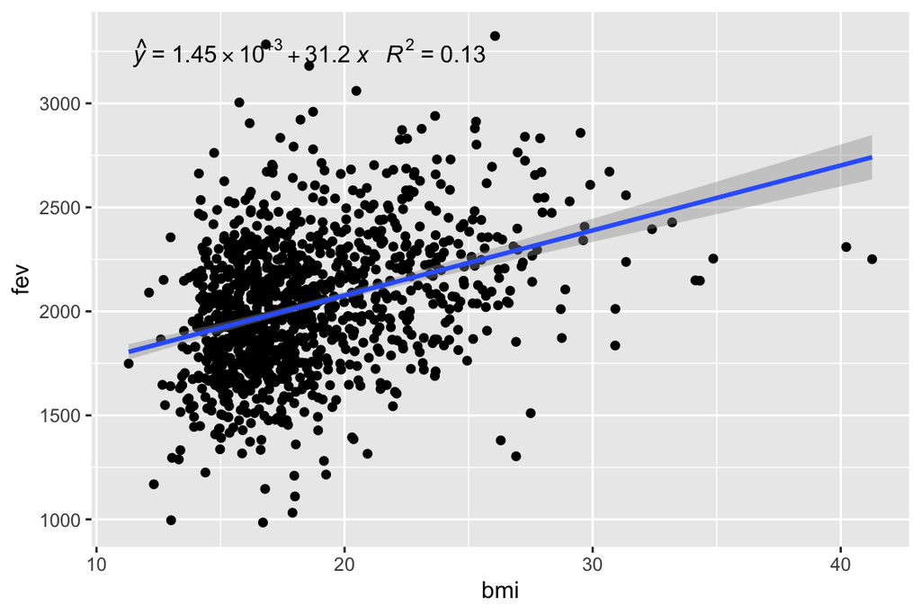

```r
# run plot with regression line
p1 <- ggplot(data, aes(x = bmi, y = fev)) +
  geom_point() +
  geom_smooth(method = "lm") +
  stat_poly_eq(formula = y ~ x,
               eq.with.lhs = "italic(hat(y))~`=`~",
               aes(label = paste(..eq.label.., ..rr.label.., sep = "~~~")),
               parse = TRUE)

print(p1)
```

```r
# run regression for statistical analysis
regression1 <- lm(fev ~ bmi, data = data)
print(regression1)
```

```
Call:
lm(formula = fev ~ bmi, data = data)

Coefficients:
(Intercept)          bmi
    1452.46        31.22
```

```r
summary(regression1)
```

```
Call:
lm(formula = fev ~ bmi, data = data)

Residuals:
    Min      1Q  Median      3Q     Max
-989.47 -193.88  -11.32  179.43 1305.46

Coefficients:
            Estimate Std. Error t value Pr(>|t|)
(Intercept)  1452.46      44.49   32.65   <2e-16 ***
bmi            31.23       2.36   13.23   <2e-16 ***
---
Signif. codes:  0 '***' 0.001 '**' 0.01 '*' 0.05 '.' 0.1 ' ' 1

Residual standard error: 297.2 on 1198 degrees of freedom
Multiple R-squared:  0.1275,    Adjusted R-squared:  0.1268
F-statistic: 175.1 on 1 and 1198 DF,  p-value: < 2.2e-16
```

**BMI and fev are positively correlated with an rsquare value of .1275. It is statistically significant with a pvalue of p-value: < 2.2e-16**

2. What is the association between smoke and gas exposure and FEV?

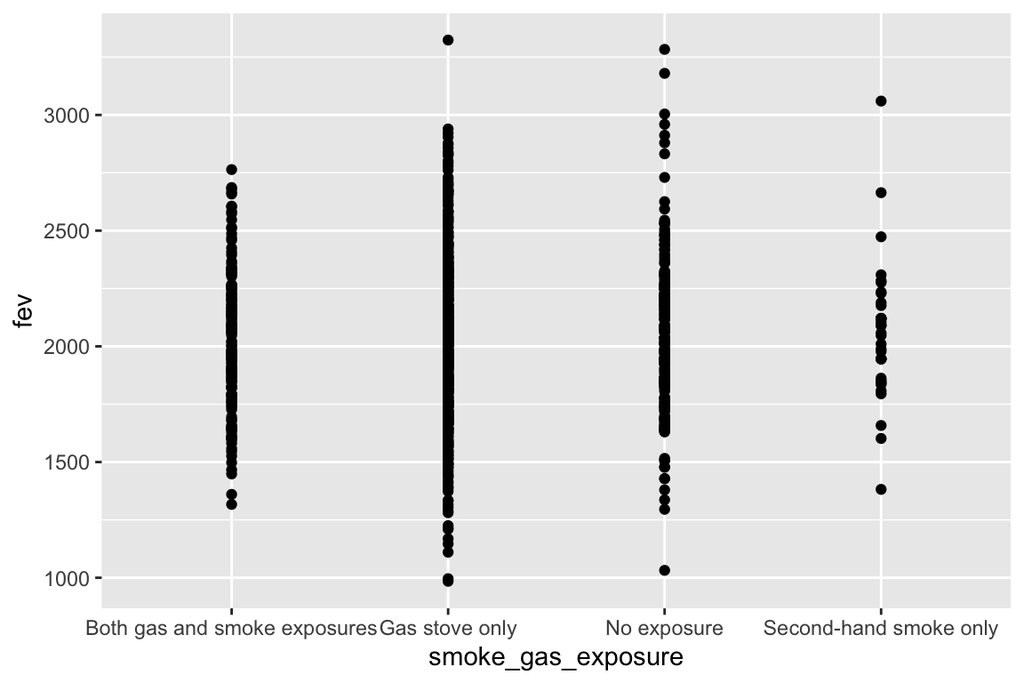

```r
#run plot
p2 <- ggplot(data, aes(x = smoke_gas_exposure, y = fev)) +
  geom_point() +
  geom_smooth(method = "lm") +
  stat_poly_eq(formula = y ~ x,
               eq.with.lhs = "italic(hat(y))~`=`~",
               aes(label = paste(..eq.label.., ..rr.label.., sep = "~~~")),
               parse = TRUE)

print(p2)
```

```r
# run regression for statistical analysis
regression2 <- lm(fev ~ smoke_gas_exposure, data = data)
print(regression2)
```

```
Call:
lm(formula = fev ~ smoke_gas_exposure, data = data)

Coefficients:
                             (Intercept)
                                2024.778
        smoke_gas_exposureGas stove only
                                  -2.107
           smoke_gas_exposureNo exposure
                                  31.915
smoke_gas_exposureSecond-hand smoke only
                                  30.936
```

```r
summary(regression2)
```

```
Call:
lm(formula = fev ~ smoke_gas_exposure, data = data)

Residuals:
    Min      1Q  Median      3Q     Max
-1037.8  -205.3   -12.0   190.7  1301.0

Coefficients:
                                         Estimate Std. Error t value Pr(>|t|)
(Intercept)                              2024.778     25.633  78.991   <2e-16
smoke_gas_exposureGas stove only           -2.107     28.017  -0.075    0.940
smoke_gas_exposureNo exposure              31.915     33.453   0.954    0.340
smoke_gas_exposureSecond-hand smoke only   30.936     58.888   0.525    0.599

(Intercept)                              ***
smoke_gas_exposureGas stove only
smoke_gas_exposureNo exposure
smoke_gas_exposureSecond-hand smoke only
---
Signif. codes:  0 '***' 0.001 '**' 0.01 '*' 0.05 '.' 0.1 ' ' 1

Residual standard error: 318.1 on 1196 degrees of freedom
Multiple R-squared:  0.001868,  Adjusted R-squared:  -0.0006354
F-statistic: 0.7462 on 3 and 1196 DF,  p-value: 0.5246
```

**smoke/gas exposure and fev have a rquared value of .001868. But it is not signifcant with a pvalue of 0.5246** 3. What is the association between PM2.5 exposure and FEV?

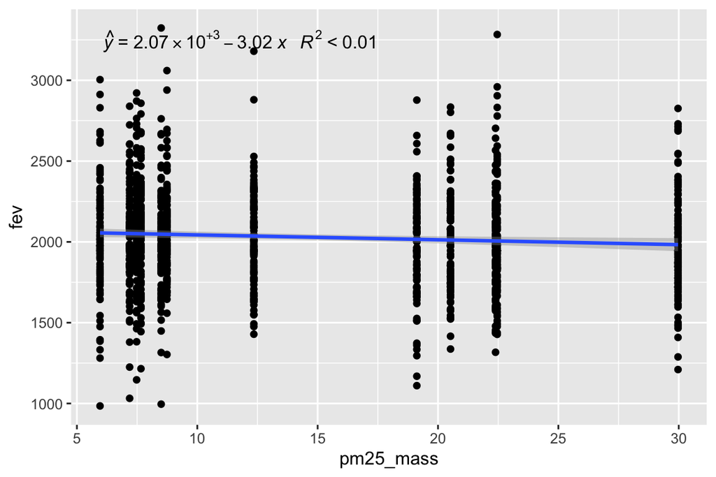

```r
# run dot plot with regression line
p3 <- ggplot(data, aes(x = pm25_mass, y = fev)) +
  geom_point() +
  geom_smooth(method = "lm") +
  stat_poly_eq(formula = y ~ x,
               eq.with.lhs = "italic(hat(y))~`=`~",
               aes(label = paste(..eq.label.., ..rr.label.., sep = "~~~")),
               parse = TRUE)

print(p3)
```

```r
# run regression for statistical analysis
regression3 <- lm(fev ~ pm25_mass, data = data)
print(regression3)
```

```
Call:
lm(formula = fev ~ pm25_mass, data = data)

Coefficients:
(Intercept)    pm25_mass
   2073.452       -3.016
```

```r
summary(regression3)
```

```
Call:
lm(formula = fev ~ pm25_mass, data = data)

Residuals:
     Min       1Q   Median       3Q      Max
-1070.63  -206.57   -13.33   195.87  1277.65

Coefficients:
            Estimate Std. Error t value Pr(>|t|)
(Intercept) 2073.452     19.309 107.383   <2e-16 ***
pm25_mass     -3.016      1.184  -2.548    0.011 *
---
Signif. codes:  0 '***' 0.001 '**' 0.01 '*' 0.05 '.' 0.1 ' ' 1

Residual standard error: 317.3 on 1198 degrees of freedom
Multiple R-squared:  0.005389,  Adjusted R-squared:  0.004559
F-statistic: 6.492 on 1 and 1198 DF,  p-value: 0.01096
```

**pm25_mass and fev appear slighlty negatively correlated with rsquare of 0.005389. It is statistically significant with a pvalue of 0.01096**

Follow the EDA checklist from week 3 and the previous assignment. Be sure to focus on the key variables.

## Visualization

Create the following figures and interpret them. Be sure to include easily understandable axes, titles, and legends.

1. Facet plot showing scatterplots with regression lines of BMI vs FEV by “townname”.

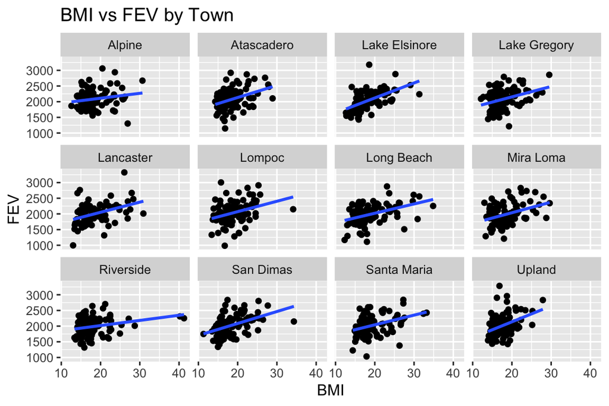

```r
facet_plot <- ggplot(data, aes(x = bmi, y = fev)) +
  geom_point() +
  geom_smooth(method = "lm", se = FALSE) +
  facet_wrap(~ townname) +
  labs(title = "BMI vs FEV by Town",
       x = "BMI",
       y = "FEV")

print(facet_plot)
```

2. Stacked histograms of FEV by BMI category and FEV by smoke/gas exposure. Use different color schemes than the ggplot default.

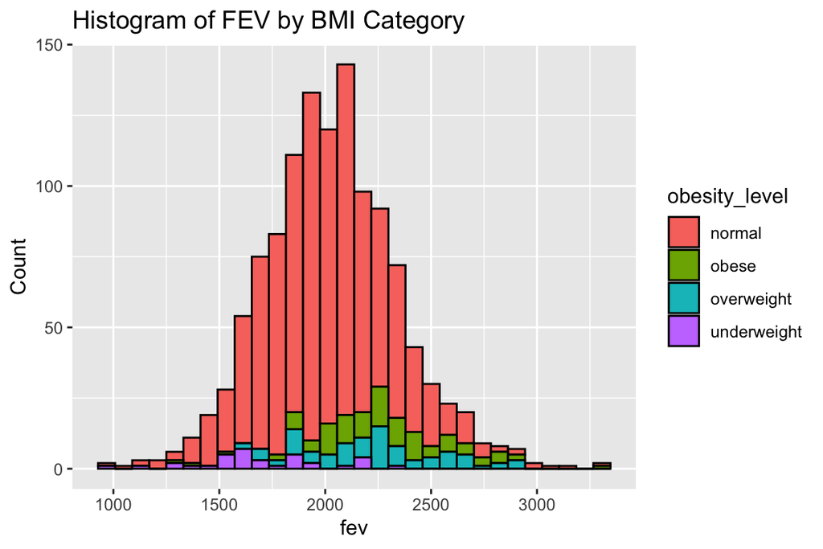

```r
# plot fev x bmi
plot2a <- ggplot(data, aes(x = fev, fill = obesity_level)) +
  geom_histogram(position = "stack", bins = 30, color = "black") +  # 30 bins can be adjusted
  labs(title = "Histogram of FEV by BMI Category",
       x = "fev",
       y = "Count")

print(plot2a)
```

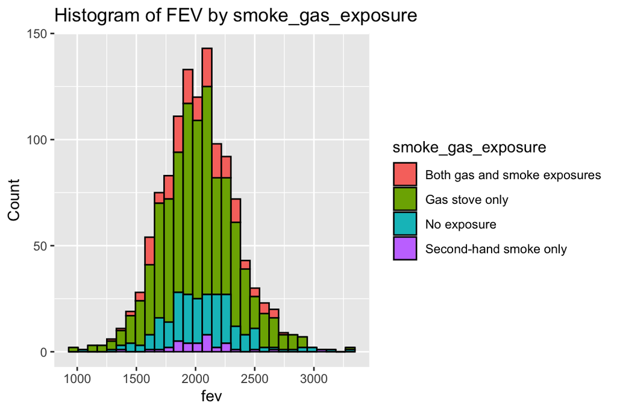

```r
#plot fev x smoke/gas
plot2b <- ggplot(data, aes(x = fev, fill = smoke_gas_exposure)) +
  geom_histogram(position = "stack", bins = 30, color = "black") +  # 30 bins can be adjusted
  labs(title = "Histogram of FEV by smoke_gas_exposure",
       x = "fev",
       y = "Count")

print(plot2b)
```

3. Barchart of BMI by smoke/gas exposure.

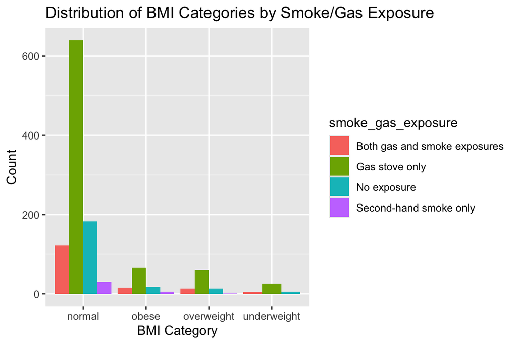

```r
plot3 <- ggplot(data, aes(x = obesity_level, fill = smoke_gas_exposure)) +
  geom_bar(position = "dodge") +
  labs(title = "Distribution of BMI Categories by Smoke/Gas Exposure",
       x = "BMI Category",
       y = "Count")

print(plot3)
```

4. Statistical summary graphs of FEV by BMI and FEV by smoke/gas exposure category.

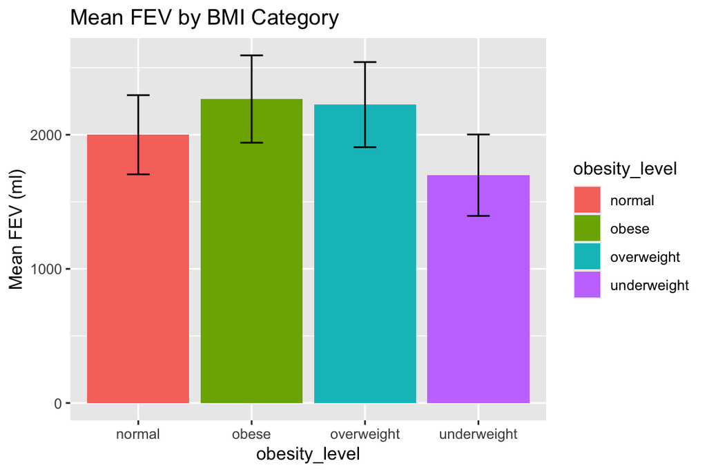

```r
#plot fev x bmi
plot4a <- ggplot(summary_obesity, aes(x = obesity_level, y = average_FEV, fill = obesity_level)) +
  geom_bar(stat = "identity", position = "dodge") +  # Use 'identity' for the summary stats
  geom_errorbar(aes(ymin = average_FEV - sd_FEV, ymax = average_FEV + sd_FEV), width = 0.2) +
  labs(title = "Mean FEV by BMI Category",
       x = "obesity_level",
       y = "Mean FEV (ml)")
print(plot4a)
```

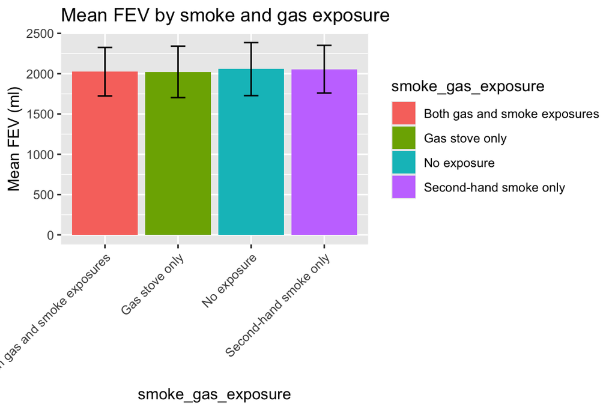

```r
#plot fev x gas exposure
plot4b <- ggplot(summary_smoke_gas, aes(x = smoke_gas_exposure, y = average_FEV, fill = smoke_gas_exposure)) +
  geom_bar(stat = "identity", position = "dodge") +  # Use 'identity' for the summary stats
  geom_errorbar(aes(ymin = average_FEV - sd_FEV, ymax = average_FEV + sd_FEV), width = 0.2) +
  labs(title = "Mean FEV by smoke and gas exposure",
       x = "smoke_gas_exposure",
       y = "Mean FEV (ml)") +
  theme(axis.text.x = element_text(angle = 45, hjust = 1))

print(plot4b)
```

5. A leaflet map showing the concentrations of PM2.5 mass in each of the CHS communities.

```r
leaflet(data = reg) %>%
  addTiles() %>%
  addCircleMarkers(
    lng = ~lon,
    lat = ~lat,
    radius = ~pm25_mass * 0.5,  # Scale the radius for better visibility
    color = "black",  # Fixed color for all markers
    stroke = FALSE,  # Remove stroke
    fillOpacity = 0.5,
    popup = ~paste(townname, "<br>", "PM2.5:", pm25_mass, "µg/m³")
  )
```

[interactive chart not shown]

6. Choose a visualization to examine whether PM2.5 mass is associated with FEV.

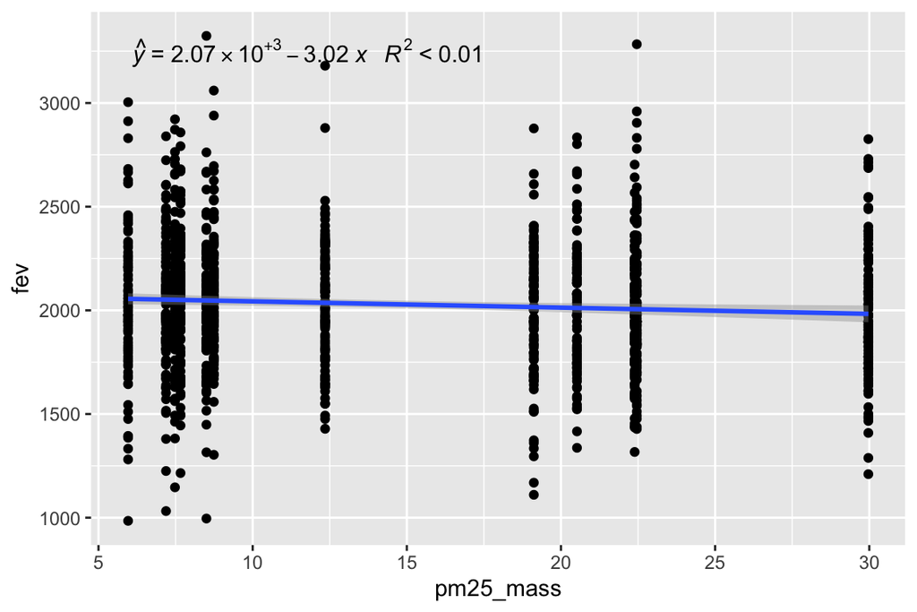

```r
p6 <- ggplot(data, aes(x = pm25_mass, y = fev)) +
  geom_point() +
  geom_smooth(method = "lm") +
  stat_poly_eq(formula = y ~ x,
               eq.with.lhs = "italic(hat(y))~`=`~",
               aes(label = paste(..eq.label.., ..rr.label.., sep = "~~~")),
               parse = TRUE)

print(p6)
```

```r
regression6 <- lm(fev ~ pm25_mass, data = data)
print(regression6)
```

```
Call:
lm(formula = fev ~ pm25_mass, data = data)

Coefficients:
(Intercept)    pm25_mass
   2073.452       -3.016
```

```r
summary(regression6)
```

```
Call:
lm(formula = fev ~ pm25_mass, data = data)

Residuals:
     Min       1Q   Median       3Q      Max
-1070.63  -206.57   -13.33   195.87  1277.65

Coefficients:
            Estimate Std. Error t value Pr(>|t|)
(Intercept) 2073.452     19.309 107.383   <2e-16 ***
pm25_mass     -3.016      1.184  -2.548    0.011 *
---
Signif. codes:  0 '***' 0.001 '**' 0.01 '*' 0.05 '.' 0.1 ' ' 1

Residual standard error: 317.3 on 1198 degrees of freedom
Multiple R-squared:  0.005389,  Adjusted R-squared:  0.004559
F-statistic: 6.492 on 1 and 1198 DF,  p-value: 0.01096
```

**pm25_mass and fev appear slighlty negatively correlated with rsquare of 0.005389. It is statistically significant with a pvalue of 0.01096**